# RCG datacall Report

Compiled on 24/04/2024, 14:48

No Landing data available

# 1 Detailed data table

## 1.1 Summary of trips

Biological data were analysed to provide a summary table reporting the number of trips/hauls monitored by year, port, metier and sampling method.

### 1.1.1 GSA1

#### 1.1.1.1 ANK

*Summary table reporting the number of trips/hauls monitored by year by port, metier, sampling method for ANK in GSA1*

| Year | Flag_country | Area | Harbour | Species | Fishing_activity_category_European_lvl_6 | Sampling_method | Nb_trips |
| --- | --- | --- | --- | --- | --- | --- | --- |
| 2022 | ESP | GSA1 | ESAGU | ANK | OTB_DEF_>=40_0_0 | Observer | 2 |
| 2022 | ESP | GSA1 | ESAGU | ANK | OTB_DWS_>=40_0_0 | Observer | 3 |
| 2022 | ESP | GSA1 | ESFGL | ANK | OTB_DEF_>=40_0_0 | Observer | 2 |
| 2022 | ESP | GSA1 | ESLEI | ANK | OTB_DEF_>=40_0_0 | Observer | 44 |
| 2022 | ESP | GSA1 | ESLEI | ANK | OTB_DWS_>=40_0_0 | Observer | 7 |
| 2022 | ESP | GSA1 | ESMZO | ANK | OTB_DEF_>=40_0_0 | Observer | 12 |
| 2022 | ESP | GSA1 | ESMZO | ANK | OTB_DWS_>=40_0_0 | Observer | 1 |
| 2022 | ESP | GSA1 | ESVMG | ANK | OTB_DEF_>=40_0_0 | Observer | 40 |

### 1.1.2 GSA2

#### 1.1.2.1 ANK

*Summary table reporting the number of trips/hauls monitored by year by port, metier, sampling method for ANK in GSA2*

| Year | Flag_country | Area | Harbour | Species | Fishing_activity_category_European_lvl_6 | Sampling_method | Nb_trips |
| --- | --- | --- | --- | --- | --- | --- | --- |
| 2022 | ESP | GSA2 | ESADR | ANK | OTB_DWS_>=40_0_0 | Observer | 4 |
| 2022 | ESP | GSA2 | ESLEI | ANK | OTB_DWS_>=40_0_0 | Observer | 2 |
| 2022 | ESP | GSA2 | ESLEI | ANK | OTB_MDD_>=40_0_0 | Observer | 2 |

### 1.1.3 GSA5

#### 1.1.3.1 ANK

*Summary table reporting the number of trips/hauls monitored by year by port, metier, sampling method for ANK in GSA5*

| Year | Flag_country | Area | Harbour | Species | Fishing_activity_category_European_lvl_6 | Sampling_method | Nb_trips |
| --- | --- | --- | --- | --- | --- | --- | --- |
| 2022 | ESP | GSA5 | ESALD | ANK | OTB_DEF_>=40_0_0 | Observer | 2 |
| 2022 | ESP | GSA5 | ESALD | ANK | OTB_MDD_>=40_0_0 | Observer | 2 |
| 2022 | ESP | GSA5 | ESCEM | ANK | OTB_DEF_>=40_0_0 | Observer | 1 |
| 2022 | ESP | GSA5 | ESCEM | ANK | OTB_MDD_>=40_0_0 | Observer | 4 |
| 2022 | ESP | GSA5 | ESMAH | ANK | OTB_DEF_>=40_0_0 | Observer | 4 |
| 2022 | ESP | GSA5 | ESMAH | ANK | OTB_DWS_>=40_0_0 | Observer | 3 |
| 2022 | ESP | GSA5 | ESMAH | ANK | OTB_MDD_>=40_0_0 | Observer | 3 |
| 2022 | ESP | GSA5 | ESPMI | ANK | OTB_DEF_>=40_0_0 | Observer | 1 |
| 2022 | ESP | GSA5 | ESPMI | ANK | OTB_DWS_>=40_0_0 | Observer | 9 |
| 2022 | ESP | GSA5 | ESPMI | ANK | OTB_MDD_>=40_0_0 | Observer | 1 |
| 2022 | ESP | GSA5 | ESPSL | ANK | OTB_DWS_>=40_0_0 | Observer | 3 |
| 2022 | ESP | GSA5 | ESPSL | ANK | OTB_MDD_>=40_0_0 | Observer | 2 |

### 1.1.4 GSA6

#### 1.1.4.1 ANK

*Summary table reporting the number of trips/hauls monitored by year by port, metier, sampling method for ANK in GSA6*

| Year | Flag_country | Area | Harbour | Species | Fishing_activity_category_European_lvl_6 | Sampling_method | Nb_trips |
| --- | --- | --- | --- | --- | --- | --- | --- |
| 2022 | ESP | GSA6 | ESAQA | ANK | OTB_DEF_>=40_0_0 | Observer | 2 |
| 2022 | ESP | GSA6 | ESAQA | ANK | OTB_DWS_>=40_0_0 | Observer | 1 |
| 2022 | ESP | GSA6 | ESBRX | ANK | OTB_DEF_>=40_0_0 | Observer | 7 |
| 2022 | ESP | GSA6 | ESCAS | ANK | OTB_DEF_>=40_0_0 | Observer | 13 |
| 2022 | ESP | GSA6 | ESCLP | ANK | OTB_DEF_>=40_0_0 | Observer | 19 |
| 2022 | ESP | GSA6 | ESDNA | ANK | OTB_DEF_>=40_0_0 | Observer | 1 |
| 2022 | ESP | GSA6 | ESDNA | ANK | OTB_DWS_>=40_0_0 | Observer | 1 |
| 2022 | ESP | GSA6 | ESJAV | ANK | OTB_DEF_>=40_0_0 | Observer | 6 |
| 2022 | ESP | GSA6 | ESJAV | ANK | OTB_DWS_>=40_0_0 | Observer | 3 |
| 2022 | ESP | GSA6 | ESJAV | ANK | OTB_MDD_>=40_0_0 | Observer | 1 |
| 2022 | ESP | GSA6 | ESPAL | ANK | OTB_DEF_>=40_0_0 | Observer | 144 |
| 2022 | ESP | GSA6 | ESPAL | ANK | OTB_DWS_>=40_0_0 | Observer | 5 |
| 2022 | ESP | GSA6 | ESPNL | ANK | OTB_DEF_>=40_0_0 | Observer | 4 |
| 2022 | ESP | GSA6 | ESSPO | ANK | GNS_DEF_>=16_0_0 | Observer | 3 |
| 2022 | ESP | GSA6 | ESSPO | ANK | OTB_DEF_>=40_0_0 | Observer | 109 |
| 2022 | ESP | GSA6 | ESSPO | ANK | OTB_MDD_>=40_0_0 | Observer | 1 |
| 2022 | ESP | GSA6 | ESTAR | ANK | OTB_DEF_>=40_0_0 | Observer | 67 |
| 2022 | ESP | GSA6 | ESTAR | ANK | OTB_DWS_>=40_0_0 | Observer | 8 |
| 2022 | ESP | GSA6 | ESTAR | ANK | OTB_MDD_>=40_0_0 | Observer | 1 |
| 2022 | ESP | GSA6 | ESTRR | ANK | OTB_DEF_>=40_0_0 | Observer | 5 |
| 2022 | ESP | GSA6 | ESVJY | ANK | OTB_DEF_>=40_0_0 | Observer | 20 |
| 2022 | ESP | GSA6 | ESVJY | ANK | OTB_DWS_>=40_0_0 | Observer | 5 |

### 1.1.5 GSA7

#### 1.1.5.1 ANK

*Summary table reporting the number of trips/hauls monitored by year by port, metier, sampling method for ANK in GSA7*

| Year | Flag_country | Area | Harbour | Species | Fishing_activity_category_European_lvl_6 | Sampling_method | Nb_trips |
| --- | --- | --- | --- | --- | --- | --- | --- |
| 2022 | ESP | GSA7 | ESLLC | ANK | LLS_DEF_0_0_0 | Observer | 1 |

## 1.2 Consistency of trip location

The consistency of trip location was checked plotting the spatial distribution of data using the initial and final coordinates, where available, and the ports position included in the data in case coordinates are not available.

Map of data spatial distribution.

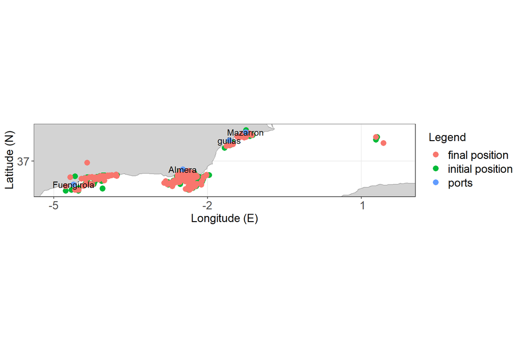

Map of data spatial distribution.

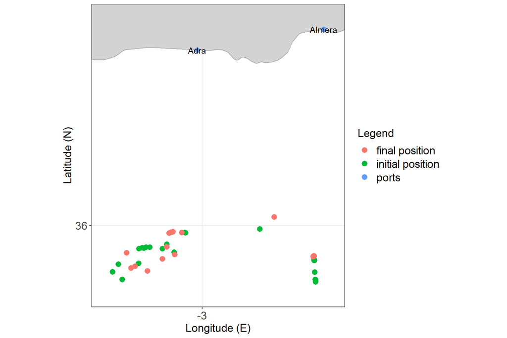

Map of data spatial distribution.

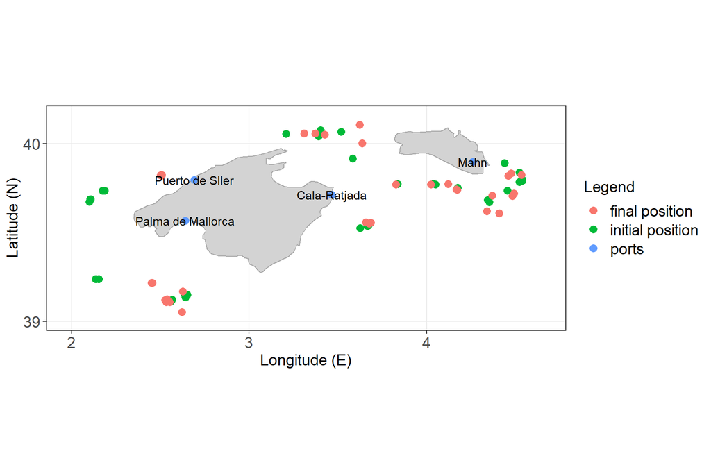

Map of data spatial distribution.

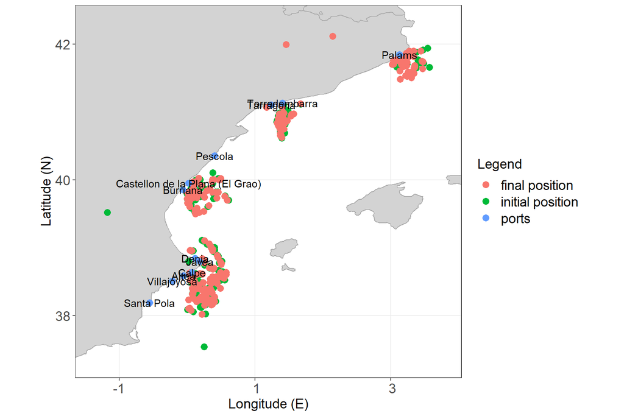

Map of data spatial distribution.

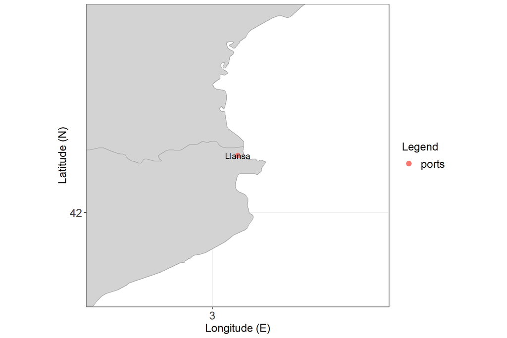

## 1.3 Summary of individual measurements

Biological data were analysed to provide a summary table reporting the number of individual by trip for which biological data have been collected (length, sex, maturity, weight and age)

### 1.3.1 GSA1

#### 1.3.1.1 ANK

*Summary table reporting the number of measurements by trip for each biological variable for ANK in GSA1*

| Year | Area | Species | Trip_code | age_data | length_measurements | maturity_data | sex_data | weight_data |
| --- | --- | --- | --- | --- | --- | --- | --- | --- |
| 2022 | GSA1 | ANK | GSA01_OTB_AGU_202201 | 0 | 7 | 0 | 7 | 0 |
| 2022 | GSA1 | ANK | GSA01_OTB_AGU_202202 | 0 | 1 | 0 | 1 | 0 |
| 2022 | GSA1 | ANK | GSA01_OTB_AGU_202203 | 0 | 14 | 0 | 14 | 0 |
| 2022 | GSA1 | ANK | GSA01_OTB_AGU_202204 | 0 | 3 | 0 | 3 | 0 |
| 2022 | GSA1 | ANK | GSA01_OTB_AGU_202206 | 0 | 4 | 0 | 4 | 0 |
| 2022 | GSA1 | ANK | GSA01_OTB_ALM_202201 | 0 | 23 | 0 | 23 | 0 |
| 2022 | GSA1 | ANK | GSA01_OTB_ALM_202202 | 0 | 1 | 0 | 1 | 0 |
| 2022 | GSA1 | ANK | GSA01_OTB_ALM_202203 | 0 | 3 | 0 | 3 | 0 |
| 2022 | GSA1 | ANK | GSA01_OTB_ALM_202204 | 0 | 25 | 0 | 25 | 0 |
| 2022 | GSA1 | ANK | GSA01_OTB_ALM_202205 | 0 | 11 | 0 | 11 | 0 |
| 2022 | GSA1 | ANK | GSA01_OTB_ALM_202206 | 0 | 6 | 0 | 6 | 0 |
| 2022 | GSA1 | ANK | GSA01_OTB_ALM_202207 | 0 | 6 | 0 | 6 | 0 |
| 2022 | GSA1 | ANK | GSA01_OTB_ALM_202208 | 0 | 5 | 0 | 5 | 0 |
| 2022 | GSA1 | ANK | GSA01_OTB_ALM_202209 | 0 | 2 | 0 | 2 | 0 |
| 2022 | GSA1 | ANK | GSA01_OTB_ALM_202210 | 0 | 13 | 0 | 13 | 0 |
| 2022 | GSA1 | ANK | GSA01_OTB_ALM_202211 | 0 | 13 | 0 | 13 | 0 |
| 2022 | GSA1 | ANK | GSA01_OTB_ALM_202212 | 0 | 10 | 0 | 10 | 0 |
| 2022 | GSA1 | ANK | GSA01_OTB_ALM_202214 | 0 | 21 | 0 | 21 | 0 |
| 2022 | GSA1 | ANK | GSA01_OTB_ALM_202215 | 0 | 4 | 0 | 4 | 0 |
| 2022 | GSA1 | ANK | GSA01_OTB_ALM_202216 | 0 | 16 | 0 | 16 | 0 |
| 2022 | GSA1 | ANK | GSA01_OTB_ALM_202217 | 0 | 3 | 0 | 3 | 0 |
| 2022 | GSA1 | ANK | GSA01_OTB_ALM_202218 | 0 | 1 | 0 | 1 | 0 |
| 2022 | GSA1 | ANK | GSA01_OTB_ALM_202219 | 0 | 4 | 0 | 4 | 0 |
| 2022 | GSA1 | ANK | GSA01_OTB_ALM_202220 | 0 | 18 | 0 | 18 | 0 |
| 2022 | GSA1 | ANK | GSA01_OTB_ALM_202221 | 0 | 11 | 0 | 11 | 0 |
| 2022 | GSA1 | ANK | GSA01_OTB_ALM_202222 | 0 | 9 | 0 | 9 | 0 |
| 2022 | GSA1 | ANK | GSA01_OTB_ALM_202223 | 0 | 3 | 0 | 3 | 0 |
| 2022 | GSA1 | ANK | GSA01_OTB_ALM_202225 | 0 | 10 | 0 | 10 | 0 |
| 2022 | GSA1 | ANK | GSA01_OTB_ALM_202226 | 0 | 5 | 0 | 5 | 0 |
| 2022 | GSA1 | ANK | GSA01_OTB_ALM_202227 | 0 | 6 | 0 | 6 | 0 |

[output cut: 81 more lines]

### 1.3.2 GSA2

#### 1.3.2.1 ANK

*Summary table reporting the number of measurements by trip for each biological variable for ANK in GSA2*

| Year | Area | Species | Trip_code | age_data | length_measurements | maturity_data | sex_data | weight_data |
| --- | --- | --- | --- | --- | --- | --- | --- | --- |
| 2022 | GSA2 | ANK | GSA02_OTB_ALM_202201 | 0 | 4 | 0 | 4 | 0 |
| 2022 | GSA2 | ANK | GSA02_OTB_ALM_202202 | 0 | 1 | 0 | 1 | 0 |
| 2022 | GSA2 | ANK | GSA02_OTB_ALM_202203 | 0 | 1 | 0 | 1 | 0 |
| 2022 | GSA2 | ANK | GSA02_OTB_ALM_202206 | 0 | 1 | 0 | 1 | 0 |
| 2022 | GSA2 | ANK | GSA02_OTB_ALM_202207 | 0 | 90 | 0 | 90 | 0 |
| 2022 | GSA2 | ANK | GSA02_OTB_ALM_202208 | 0 | 14 | 0 | 14 | 0 |
| 2022 | GSA2 | ANK | GSA02_OTB_ALM_202209 | 0 | 4 | 0 | 4 | 0 |
| 2022 | GSA2 | ANK | GSA02_OTB_ALM_202210 | 0 | 7 | 0 | 7 | 0 |

### 1.3.3 GSA5

#### 1.3.3.1 ANK

*Summary table reporting the number of measurements by trip for each biological variable for ANK in GSA5*

| Year | Area | Species | Trip_code | age_data | length_measurements | maturity_data | sex_data | weight_data |
| --- | --- | --- | --- | --- | --- | --- | --- | --- |
| 2022 | GSA5 | ANK | GSA05_OTB_ALC_202201 | 0 | 5 | 0 | 5 | 0 |
| 2022 | GSA5 | ANK | GSA05_OTB_ALC_202203 | 0 | 11 | 0 | 11 | 0 |
| 2022 | GSA5 | ANK | GSA05_OTB_ALC_202205 | 0 | 1 | 0 | 1 | 0 |
| 2022 | GSA5 | ANK | GSA05_OTB_ALC_202206 | 0 | 1 | 0 | 1 | 0 |
| 2022 | GSA5 | ANK | GSA05_OTB_CRA_202203 | 0 | 1 | 0 | 1 | 0 |
| 2022 | GSA5 | ANK | GSA05_OTB_CRA_202206 | 0 | 1 | 0 | 1 | 0 |
| 2022 | GSA5 | ANK | GSA05_OTB_CRA_202209 | 0 | 1 | 0 | 1 | 0 |
| 2022 | GSA5 | ANK | GSA05_OTB_CRA_202210 | 0 | 1 | 0 | 1 | 0 |
| 2022 | GSA5 | ANK | GSA05_OTB_CRA_202218 | 0 | 3 | 0 | 3 | 0 |
| 2022 | GSA5 | ANK | GSA05_OTB_MAH_202202 | 0 | 7 | 0 | 7 | 0 |
| 2022 | GSA5 | ANK | GSA05_OTB_MAH_202207 | 0 | 2 | 0 | 2 | 0 |
| 2022 | GSA5 | ANK | GSA05_OTB_MAH_202209 | 0 | 1 | 0 | 1 | 0 |
| 2022 | GSA5 | ANK | GSA05_OTB_MAH_202211 | 0 | 1 | 0 | 1 | 0 |
| 2022 | GSA5 | ANK | GSA05_OTB_MAH_202213 | 0 | 4 | 0 | 4 | 0 |
| 2022 | GSA5 | ANK | GSA05_OTB_MAH_202214 | 0 | 17 | 0 | 17 | 0 |
| 2022 | GSA5 | ANK | GSA05_OTB_MAH_202215 | 0 | 30 | 0 | 30 | 0 |
| 2022 | GSA5 | ANK | GSA05_OTB_MAH_202216 | 0 | 9 | 0 | 9 | 0 |
| 2022 | GSA5 | ANK | GSA05_OTB_MAH_202219 | 0 | 7 | 0 | 7 | 0 |
| 2022 | GSA5 | ANK | GSA05_OTB_MAH_202221 | 0 | 3 | 0 | 3 | 0 |
| 2022 | GSA5 | ANK | GSA05_OTB_PMI_202201 | 0 | 6 | 0 | 6 | 0 |
| 2022 | GSA5 | ANK | GSA05_OTB_PMI_202202 | 0 | 18 | 0 | 18 | 0 |
| 2022 | GSA5 | ANK | GSA05_OTB_PMI_202203 | 0 | 25 | 0 | 25 | 0 |
| 2022 | GSA5 | ANK | GSA05_OTB_PMI_202204 | 0 | 2 | 0 | 2 | 0 |
| 2022 | GSA5 | ANK | GSA05_OTB_PMI_202205 | 0 | 6 | 0 | 6 | 0 |
| 2022 | GSA5 | ANK | GSA05_OTB_PMI_202206 | 0 | 2 | 0 | 2 | 0 |
| 2022 | GSA5 | ANK | GSA05_OTB_PMI_202207 | 0 | 1 | 0 | 1 | 0 |
| 2022 | GSA5 | ANK | GSA05_OTB_PMI_202211 | 0 | 1 | 0 | 1 | 0 |
| 2022 | GSA5 | ANK | GSA05_OTB_PMI_202212 | 0 | 2 | 0 | 2 | 0 |
| 2022 | GSA5 | ANK | GSA05_OTB_PMI_202214 | 0 | 1 | 0 | 1 | 0 |
| 2022 | GSA5 | ANK | GSA05_OTB_PMI_202220 | 0 | 7 | 0 | 7 | 0 |
| 2022 | GSA5 | ANK | GSA05_OTB_SOL_202201 | 0 | 1 | 0 | 1 | 0 |
| 2022 | GSA5 | ANK | GSA05_OTB_SOL_202202 | 0 | 1 | 0 | 1 | 0 |
| 2022 | GSA5 | ANK | GSA05_OTB_SOL_202203 | 0 | 1 | 0 | 1 | 0 |
| 2022 | GSA5 | ANK | GSA05_OTB_SOL_202206 | 0 | 1 | 0 | 1 | 0 |
| 2022 | GSA5 | ANK | GSA05_OTB_SOL_202212 | 0 | 2 | 0 | 2 | 0 |

### 1.3.4 GSA6

#### 1.3.4.1 ANK

*Summary table reporting the number of measurements by trip for each biological variable for ANK in GSA6*

| Year | Area | Species | Trip_code | age_data | length_measurements | maturity_data | sex_data | weight_data |
| --- | --- | --- | --- | --- | --- | --- | --- | --- |
| 2022 | GSA6 | ANK | 2022-01-19_0708_205_100_000640_OTB-DES-G6 | 0 | 34 | 0 | 34 | 0 |
| 2022 | GSA6 | ANK | 2022-01-19_0708_205_100_016444_OTB-DES-G6 | 0 | 58 | 0 | 58 | 0 |
| 2022 | GSA6 | ANK | 2022-01-19_0708_205_100_204291_OTB-DES-G6 | 0 | 16 | 0 | 16 | 0 |
| 2022 | GSA6 | ANK | 2022-02-07_1718_203_100_201149_OTB-DES-G6 | 0 | 17 | 0 | 17 | 0 |
| 2022 | GSA6 | ANK | 2022-02-15_1718_203_100_004824_OTB-DES-G6 | 0 | 8 | 0 | 8 | 0 |
| 2022 | GSA6 | ANK | 2022-02-15_1718_203_100_012495_OTB-DES-G6 | 0 | 4 | 0 | 4 | 0 |
| 2022 | GSA6 | ANK | 2022-02-15_1718_203_100_013074_OTB-DES-G6 | 0 | 2 | 0 | 2 | 0 |
| 2022 | GSA6 | ANK | 2022-02-15_1718_203_100_015741_OTB-DES-G6 | 0 | 5 | 0 | 5 | 0 |
| 2022 | GSA6 | ANK | 2022-02-15_1718_203_100_201149_OTB-DES-G6 | 0 | 2 | 0 | 2 | 0 |
| 2022 | GSA6 | ANK | 2022-02-15_1718_203_100_204737_OTB-DES-G6 | 0 | 9 | 0 | 9 | 0 |
| 2022 | GSA6 | ANK | 2022-02-16_1718_203_100_013074_OTB-DES-G6 | 0 | 9 | 0 | 9 | 0 |
| 2022 | GSA6 | ANK | 2022-02-16_1718_203_100_016709_OTB-DES-G6 | 0 | 1 | 0 | 1 | 0 |
| 2022 | GSA6 | ANK | 2022-02-16_1718_203_100_201079_OTB-DES-G6 | 0 | 4 | 0 | 4 | 0 |
| 2022 | GSA6 | ANK | 2022-02-16_1718_203_100_201149_OTB-DES-G6 | 0 | 10 | 0 | 10 | 0 |
| 2022 | GSA6 | ANK | 2022-02-16_1718_203_100_201428_OTB-DES-G6 | 0 | 4 | 0 | 4 | 0 |
| 2022 | GSA6 | ANK | 2022-02-16_1718_203_100_202648_OTB-DES-G6 | 0 | 14 | 0 | 14 | 0 |
| 2022 | GSA6 | ANK | 2022-02-16_1718_203_100_204068_OTB-DES-G6 | 0 | 2 | 0 | 2 | 0 |
| 2022 | GSA6 | ANK | 2022-02-28_0708_205_100_015456_OTB-DES-G6 | 0 | 28 | 0 | 28 | 0 |
| 2022 | GSA6 | ANK | 2022-02-28_0708_205_100_015856_OTB-DES-G6 | 0 | 36 | 0 | 36 | 0 |
| 2022 | GSA6 | ANK | 2022-02-28_0708_205_100_016444_OTB-DES-G6 | 0 | 69 | 0 | 69 | 0 |
| 2022 | GSA6 | ANK | 2022-03-07_1718_203_100_012495_OTB-DES-G6 | 0 | 2 | 0 | 2 | 0 |
| 2022 | GSA6 | ANK | 2022-03-07_1718_203_100_206471_OTB-DES-G6 | 0 | 2 | 0 | 2 | 0 |
| 2022 | GSA6 | ANK | 2022-03-08_1718_203_100_004824_OTB-DES-G6 | 0 | 8 | 0 | 8 | 0 |
| 2022 | GSA6 | ANK | 2022-03-08_1718_203_100_016709_OTB-DES-G6 | 0 | 1 | 0 | 1 | 0 |
| 2022 | GSA6 | ANK | 2022-03-08_1718_203_100_201079_OTB-DES-G6 | 0 | 1 | 0 | 1 | 0 |
| 2022 | GSA6 | ANK | 2022-03-08_1718_203_100_201149_OTB-DES-G6 | 0 | 7 | 0 | 7 | 0 |
| 2022 | GSA6 | ANK | 2022-03-08_1718_203_100_204737_OTB-DES-G6 | 0 | 1 | 0 | 1 | 0 |
| 2022 | GSA6 | ANK | 2022-03-09_0708_205_100_000640_OTB-DES-G6 | 0 | 23 | 0 | 23 | 0 |
| 2022 | GSA6 | ANK | 2022-03-09_0708_205_100_015856_OTB-DES-G6 | 0 | 32 | 0 | 32 | 0 |
| 2022 | GSA6 | ANK | 2022-03-09_0708_205_100_016444_OTB-DES-G6 | 0 | 35 | 0 | 35 | 0 |

[output cut: 396 more lines]

### 1.3.5 GSA7

#### 1.3.5.1 ANK

*Summary table reporting the number of measurements by trip for each biological variable for ANK in GSA7*

| Year | Area | Species | Trip_code | age_data | length_measurements | maturity_data | sex_data | weight_data |
| --- | --- | --- | --- | --- | --- | --- | --- | --- |
| 2022 | GSA7 | ANK | 2022-08-11_0736_207_302_201357_LLS-DES-G7 | 0 | 1 | 0 | 1 | 0 |

## 1.4 Consistency of LFD by year

The consistency of length frequency distributions (LFDs) was checked generating a multi-frame plot of the LFD by year. The Grubbs’ test was performed to evaluate whether the minimum and the maximum values of Length class distribution could be considered as outliers. In case, a table reporting the outliers is returned.

### 1.4.1 GSA1

#### 1.4.1.1 ANK

Plot of LFDs by year for ANK - ESP - GSA1

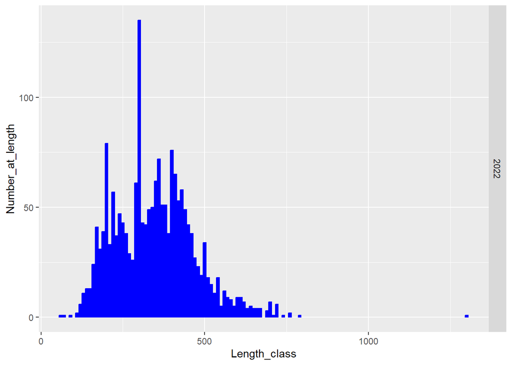

*Outliers of the length distribution for ANK in GSA1*

|  | Flag_country | Year | Trip_code | Date | Area | Commercial_size_category | Age | Sex | Length_class | fish_ID |
| --- | --- | --- | --- | --- | --- | --- | --- | --- | --- | --- |
| 22 | ESP | 2022 | GSA01_OTB_AGU_202204 | 29/06/2022 | GSA1 | NA | NA | N | 1300 | NA |

### 1.4.2 GSA2

#### 1.4.2.1 ANK

Plot of LFDs by year for ANK - ESP - GSA2

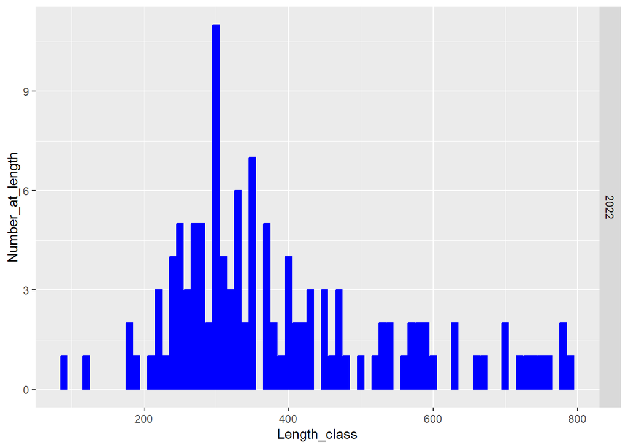

- No outliers detected in length data

### 1.4.3 GSA5

#### 1.4.3.1 ANK

Plot of LFDs by year for ANK - ESP - GSA5

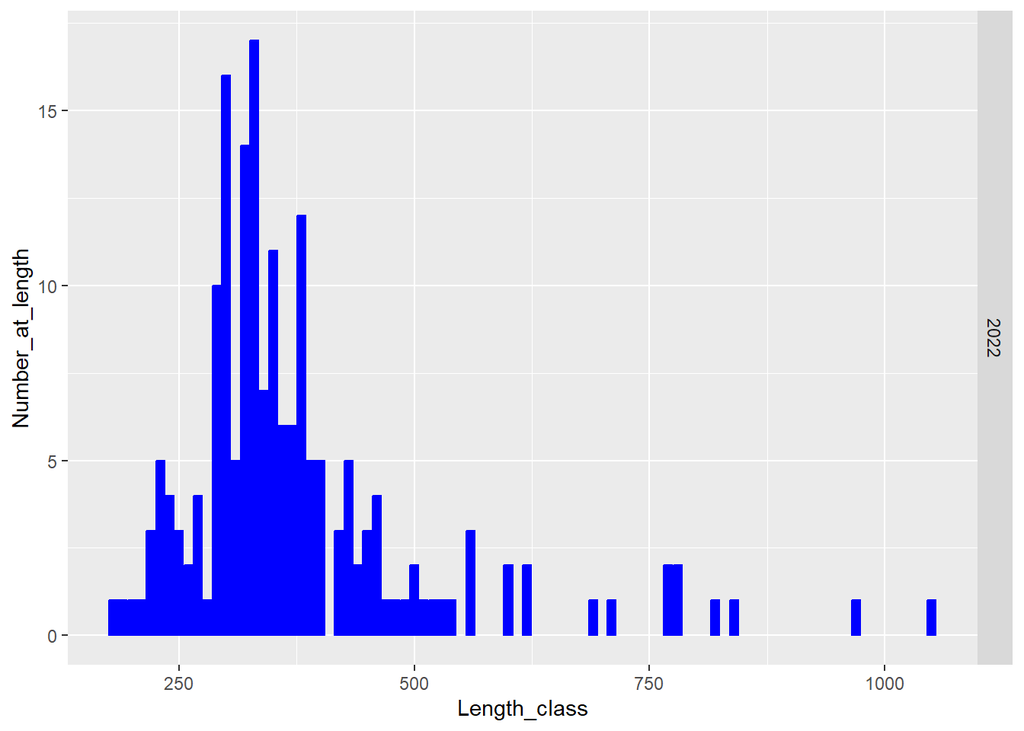

*Outliers of the length distribution for ANK in GSA5*

|  | Flag_country | Year | Trip_code | Date | Area | Commercial_size_category | Age | Sex | Length_class | fish_ID |
| --- | --- | --- | --- | --- | --- | --- | --- | --- | --- | --- |
| 1664 | ESP | 2022 | GSA05_OTB_PMI_202202 | 25/01/2022 | GSA5 | NA | NA | N | 1050 | NA |

### 1.4.4 GSA6

#### 1.4.4.1 ANK

Plot of LFDs by year for ANK - ESP - GSA6

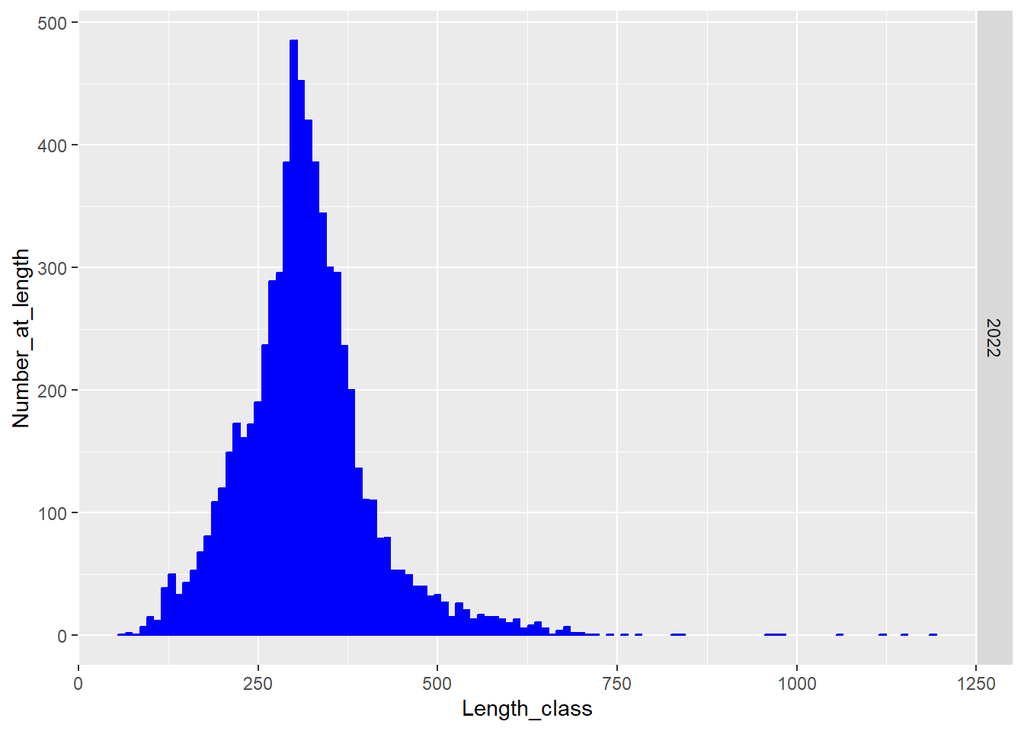

*Outliers of the length distribution for ANK in GSA6*

|  | Flag_country | Year | Trip_code | Date | Area | Commercial_size_category | Age | Sex | Length_class | fish_ID |
| --- | --- | --- | --- | --- | --- | --- | --- | --- | --- | --- |
| 1715 | ESP | 2022 | GSA06_OTB_ALT_202203 | 09/08/2022 | GSA6 | NA | NA | N | 1190 | NA |

### 1.4.5 GSA7

#### 1.4.5.1 ANK

Plot of LFDs by year for ANK - ESP - GSA7

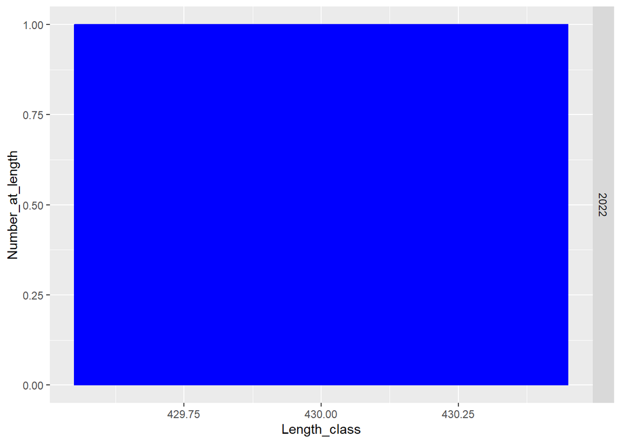

- No outliers detected in length data

## 1.5 Consistency of LFD by year and commercial category

The consistency of length frequency distributions (LFD) was checked generating a multi-frame plot of the LFD by year and commercial size categories.

### 1.5.1 GSA1

#### 1.5.1.1 ANK

Plot of LFDs by year and commercial size category for ANK - ESP - GSA1

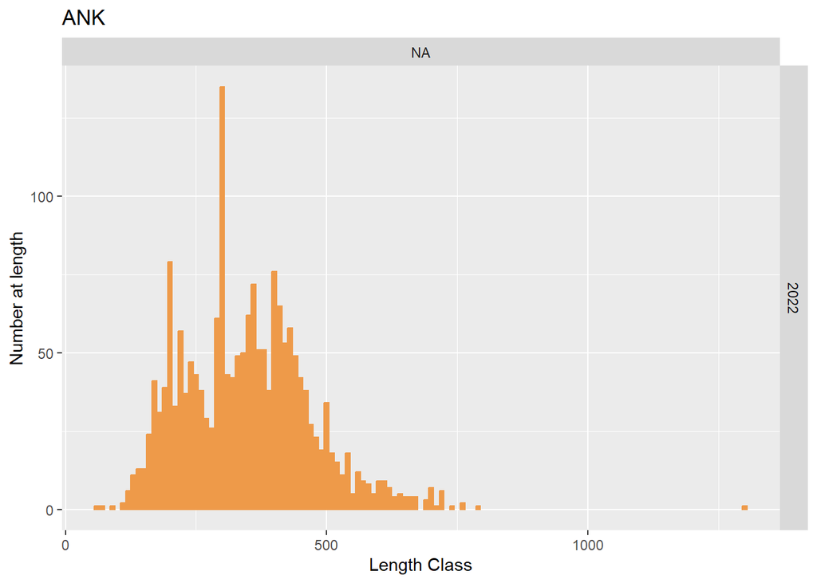

### 1.5.2 GSA2

#### 1.5.2.1 ANK

Plot of LFDs by year and commercial size category for ANK - ESP - GSA2

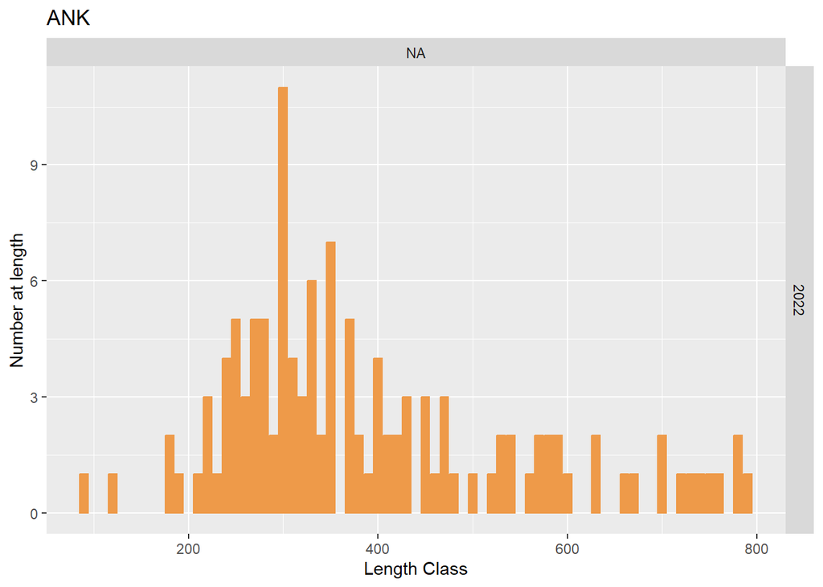

### 1.5.3 GSA5

#### 1.5.3.1 ANK

Plot of LFDs by year and commercial size category for ANK - ESP - GSA5

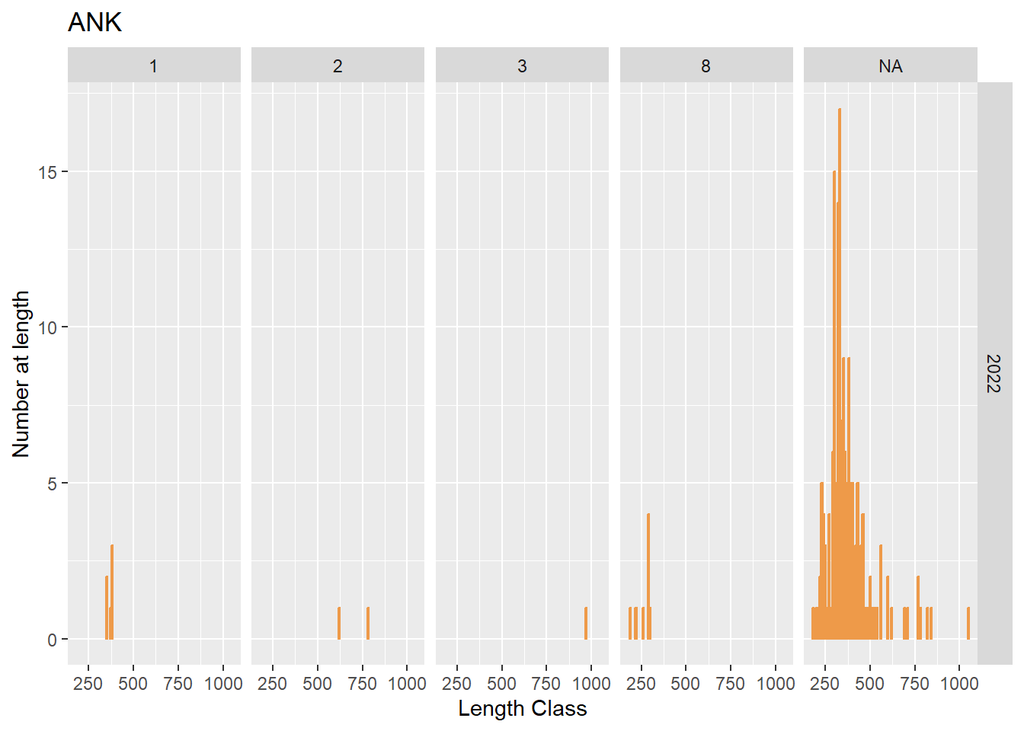

### 1.5.4 GSA6

#### 1.5.4.1 ANK

Plot of LFDs by year and commercial size category for ANK - ESP - GSA6

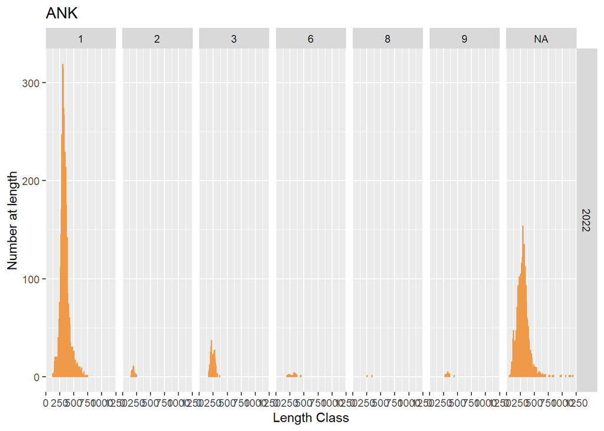

### 1.5.5 GSA7

#### 1.5.5.1 ANK

Plot of LFDs by year and commercial size category for ANK - ESP - GSA7

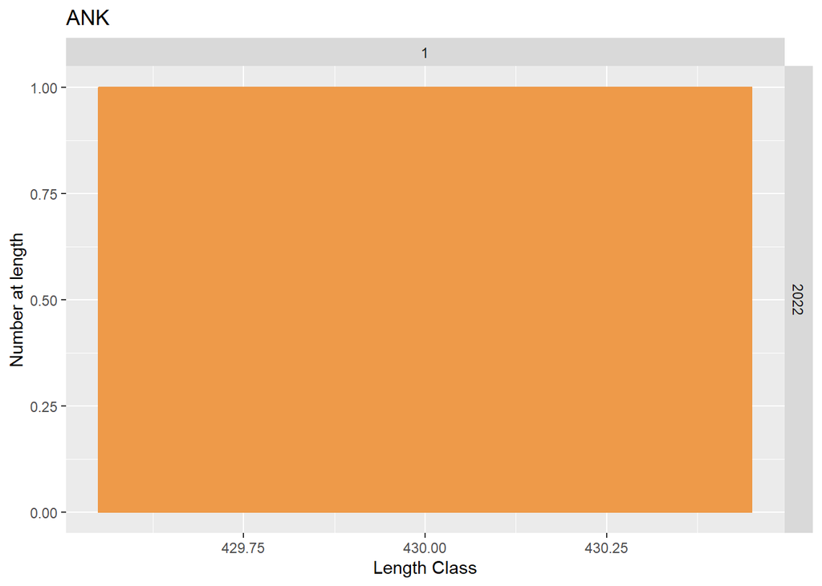

## 1.6 Consistency of sex and maturity stage

The consistency of maturity stages by sex and year was qualitatively checked accordingly to the length class.

### 1.6.1 GSA1

#### 1.6.1.1 ANK

- No data available for ANK - ESP - GSA1

### 1.6.2 GSA2

#### 1.6.2.1 ANK

- No data available for ANK - ESP - GSA2

### 1.6.3 GSA5

#### 1.6.3.1 ANK

- No data available for ANK - ESP - GSA5

### 1.6.4 GSA6

#### 1.6.4.1 ANK

- No data available for ANK - ESP - GSA6

### 1.6.5 GSA7

#### 1.6.5.1 ANK

- No data available for ANK - ESP - GSA7

## 1.7 Check of maturity ogive

The maturity stages composition was checked estimating the maturity ogives by sex for: ANK. ‘0’, ‘1’ and ‘2a’ were considered as immature stages.

### 1.7.1 GSA1

#### 1.7.1.1 ANK

- No males’ data available for ANK - ESP - GSA1
- No females’ data available for ANK - ESP - GSA1

### 1.7.2 GSA2

#### 1.7.2.1 ANK

- No males’ data available for ANK - ESP - GSA2
- No females’ data available for ANK - ESP - GSA2

### 1.7.3 GSA5

#### 1.7.3.1 ANK

- No males’ data available for ANK - ESP - GSA5
- No females’ data available for ANK - ESP - GSA5

### 1.7.4 GSA6

#### 1.7.4.1 ANK

- No males’ data available for ANK - ESP - GSA6
- No females’ data available for ANK - ESP - GSA6

### 1.7.5 GSA7

#### 1.7.5.1 ANK

- No males’ data available for ANK - ESP - GSA7
- No females’ data available for ANK - ESP - GSA7

## 1.8 Consistency of length-weight relationship

The consistency of length-weight relationship was checked generating a multi-frame plot of the LFD by year and sex.

### 1.8.1 GSA1

#### 1.8.1.1 ANK

- No data available for ANK - ESP - GSA1

### 1.8.2 GSA2

#### 1.8.2.1 ANK

- No data available for ANK - ESP - GSA2

### 1.8.3 GSA5

#### 1.8.3.1 ANK

- No data available for ANK - ESP - GSA5

### 1.8.4 GSA6

#### 1.8.4.1 ANK

- No data available for ANK - ESP - GSA6

### 1.8.5 GSA7

#### 1.8.5.1 ANK

- No data available for ANK - ESP - GSA7

## 1.9 Consistency of age-length relationship

RCG detailed data were checked for the consistency of the age-length data. The Grubbs’ test was performed to evaluate whether the maximum value of age distribution could be considered as outliers. In case, a table reporting the outliers is returned.

### 1.9.1 GSA1

#### 1.9.1.1 ANK

- No age data available for ANK - ESP - GSA1

### 1.9.2 GSA2

#### 1.9.2.1 ANK

- No age data available for ANK - ESP - GSA2

### 1.9.3 GSA5

#### 1.9.3.1 ANK

- No age data available for ANK - ESP - GSA5

### 1.9.4 GSA6

#### 1.9.4.1 ANK

- No age data available for ANK - ESP - GSA6

### 1.9.5 GSA7

#### 1.9.5.1 ANK

- No age data available for ANK - ESP - GSA7